# Un petit cours sur les graphiques (avec ggplot)

### Diagrammes xy - la magie des corrélations

venons en à analyser les relation entre deux variables quantitatives.

on a donc appris à comparer dplusieurs distributions, les moyennes de plusieurs variables qualitative, examinons les relation entre deucx variables quantitatibe

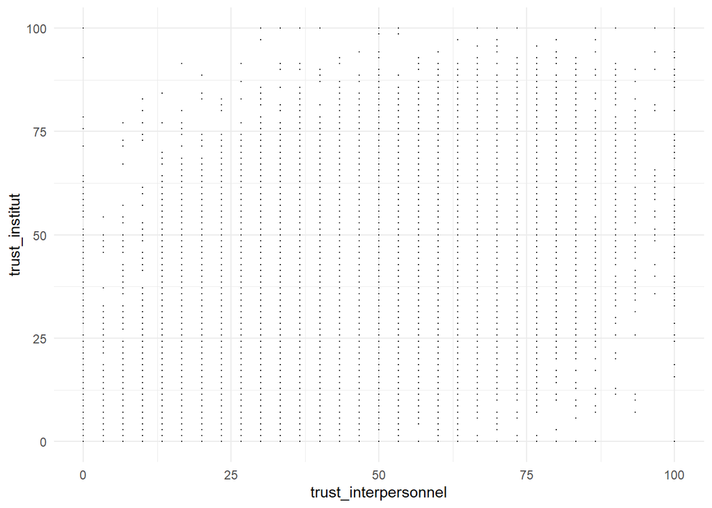

```r
g31<- ggplot(df, aes(x= trust_interpersonnel,y=trust_institut, group=Year)) +
  geom_point( size=0.1)+
  theme_minimal()
g31
```

Ce graphe est peu clair, ils y a trop de points qui prennent des valeurs discrètes. Une astuce estde donner une position aléatoire pour sur disperser, on fait mieux apparaitre la densité de points.

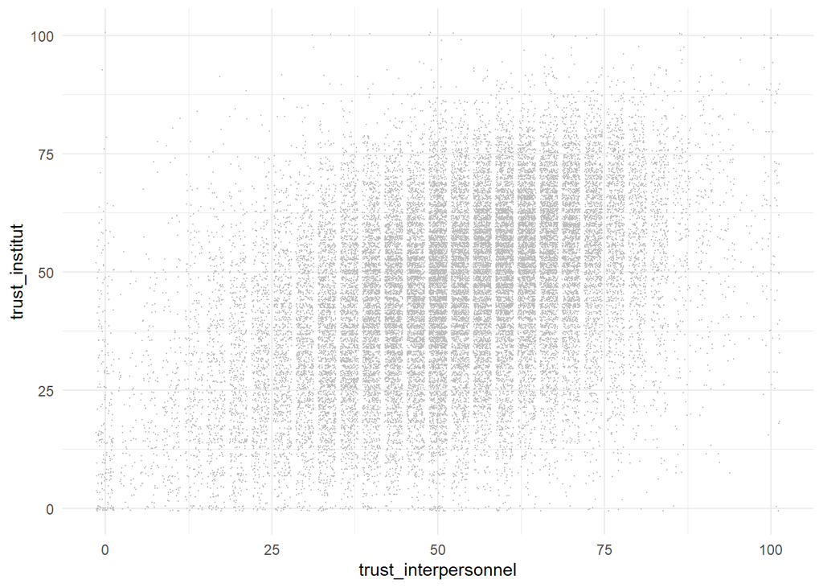

```r
g32<-ggplot(df, aes(x= trust_interpersonnel,y=trust_institut, group=Year)) +
  geom_point(position = "jitter", size=0.1, color="grey")+
  theme_minimal()
g32
```

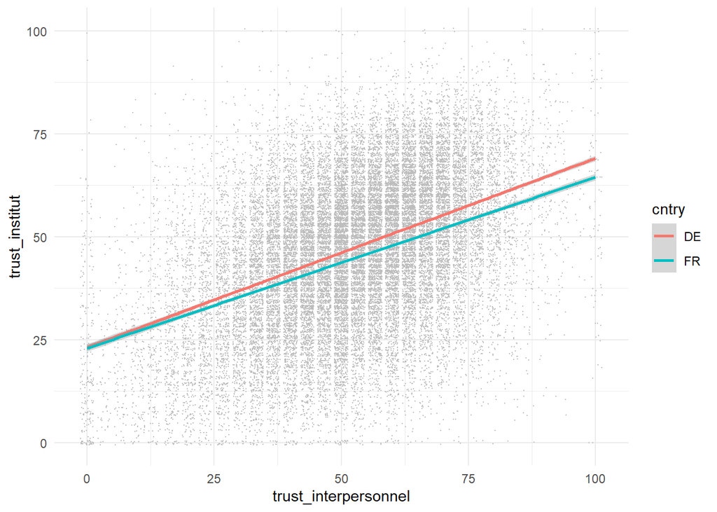

```r
df0<-df%>% filter(!is.na(Year))
g3<-ggplot(df0, aes(x= trust_interpersonnel,y=trust_institut, group=cntry)) +
  geom_point(position = "jitter", size=0.1, color="grey")+geom_smooth(method="lm", aes(color=cntry))+theme_minimal()
g3
```

Mais en attendant en voci un calcul élémentaire. Le r² est de 0,18, la corrélation est de l’ordre d’un peu plus 0,42 ce qui est assez élevé mais laisse une certaine indépendance des variables. Elle désignent des objets liés mais différents.

```r
cor.test(df$trust_interpersonnel, df$trust_institut)
```

```
##
##  Pearson's product-moment correlation
##
## data:  df$trust_interpersonnel and df$trust_institut
## t = 87.126, df = 34985, p-value < 2.2e-16
## alternative hypothesis: true correlation is not equal to 0
## 95 percent confidence interval:
##  0.4135963 0.4308171
## sample estimates:
##       cor
## 0.4222448
```

```r
library(lme4)

fits <- lmList(trust_interpersonnel ~ trust_institut | cntry, data=df)
summary(fits)
```

```
## Call:
##   Model: trust_interpersonnel ~ trust_institut | NULL
##    Data: df
##
## Coefficients:
##    (Intercept)
##    Estimate Std. Error  t value Pr(>|t|)
## DE 33.79476  0.3013494 112.1448        0
## FR 34.34344  0.3404687 100.8711        0
##    trust_institut
##     Estimate  Std. Error  t value Pr(>|t|)
## DE 0.4126952 0.005909683 69.83372        0
## FR 0.3597752 0.007236293 49.71817        0
##
## Residual standard error: 15.12791 on 34983 degrees of freedom
```

Une autre représentation plus éclatée qui ne montre rien de plus que la régularité

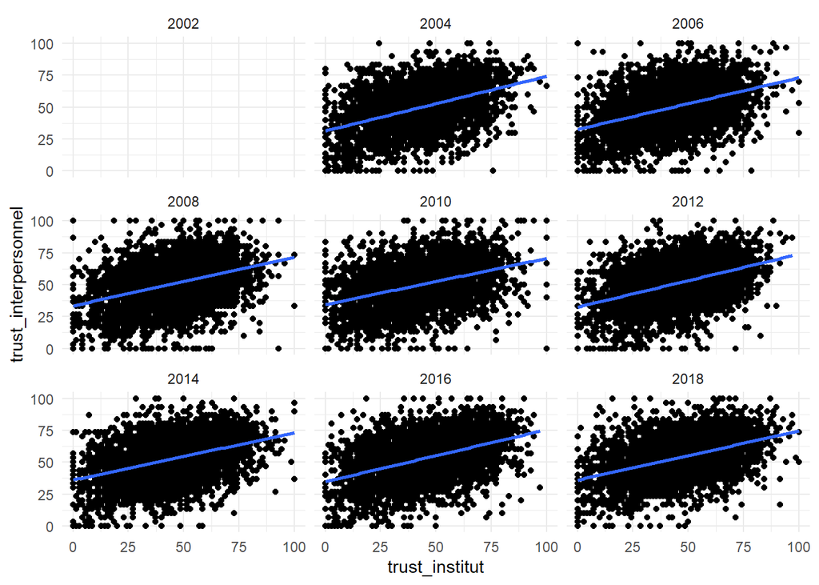

```r
ggplot(df, aes(x= trust_institut,y=trust_interpersonnel)) + geom_point() +geom_smooth(method="lm") +theme_minimal() +facet_wrap(~Year)
```

## Deux variables qualitatives

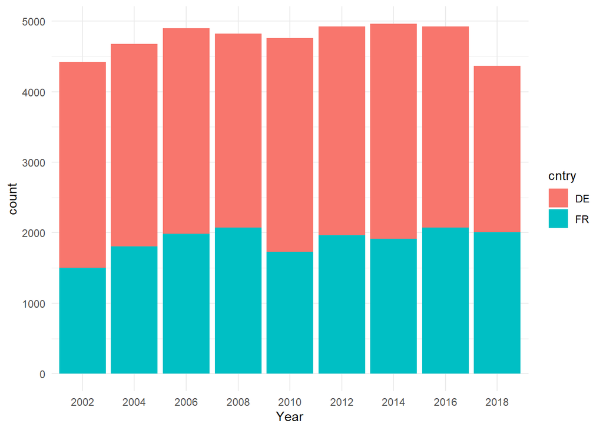

```r
g05a<-ggplot(df,aes(x=Year,y=..count..,fill=cntry))+geom_bar(position = "stack")+theme_minimal()
g05a
```

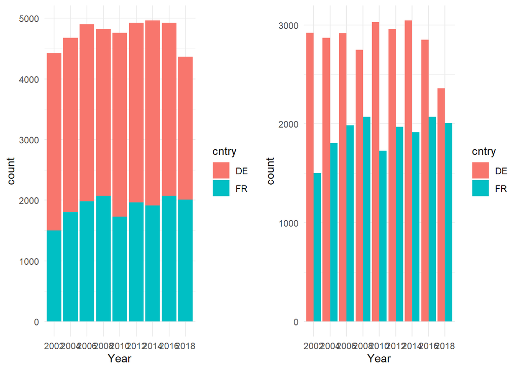

```r
g05b<-ggplot(df,aes(x=Year,y=..count..,fill=cntry))+geom_bar(position = "dodge")+theme_minimal()
grid.arrange(g05a,g05b,ncol=2)
```

## Les treemaps, c’est merveilleux

D’autre graphiques et des emboitements

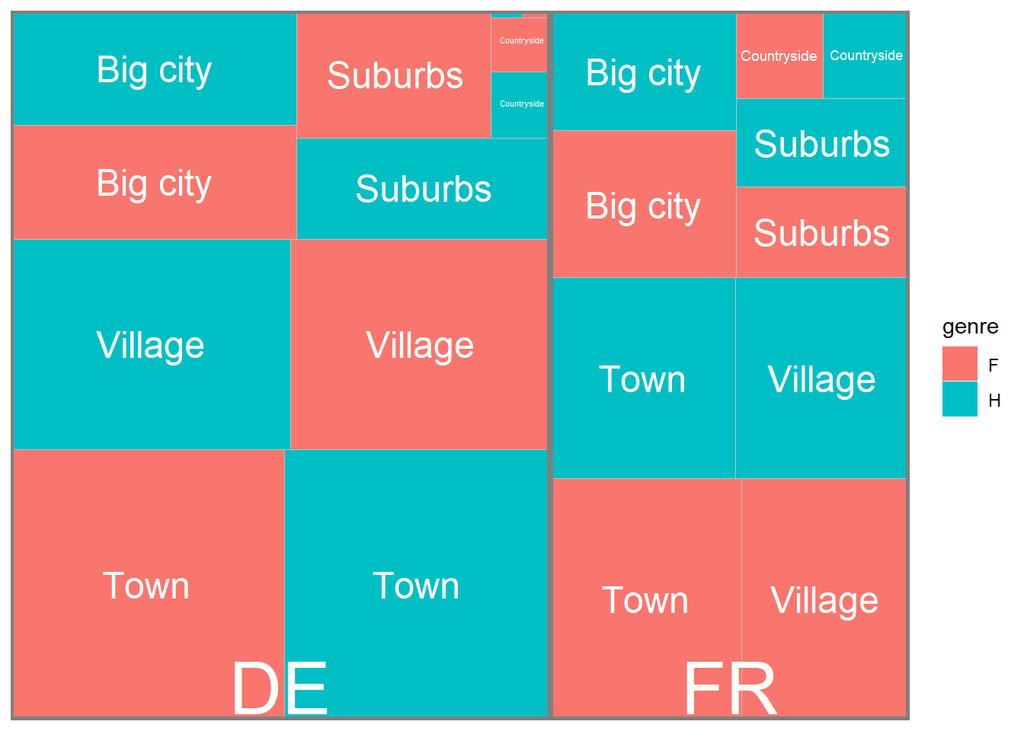

```r
library(treemapify)
tree1<-df %>% mutate(n=1)%>%group_by(cntry,genre,habitat) %>% summarize(n=sum(n),mean=mean(trust_interpersonnel, na.rm=TRUE))

g10 <- ggplot(tree1, aes(area = n, fill=genre,subgroup=cntry)) +
  geom_treemap() +
  geom_treemap_text(aes(label=habitat),colour = "white", place = "centre",grow = FALSE)+
      geom_treemap_subgroup_text(color="white",grow = FALSE)+geom_treemap_subgroup_border()
g10
```

# Examiner beaucoups de variables

Nous nous sommes concentrés sur des index. Par exemple nous avons traité la confiance instititutionnelle. Mais on peut vouloir traiter ensemble tous les items, on en a 7.

## Profils

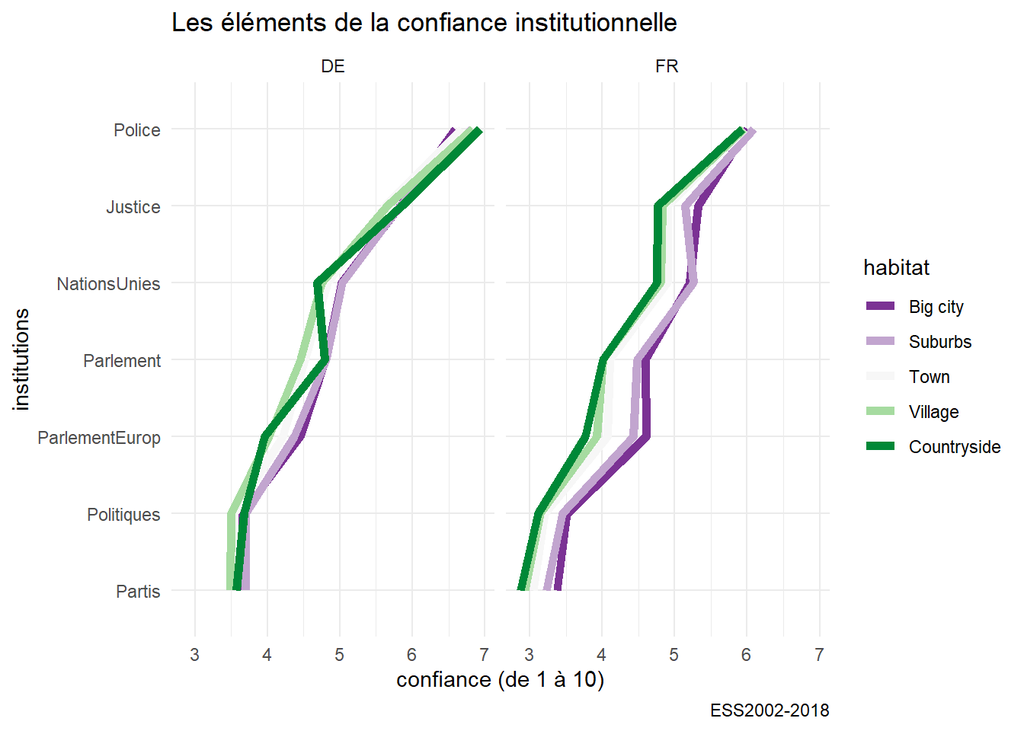

```r
rad<-df %>%
  group_by (habitat,cntry) %>%
  summarize(Partis=mean(Partis, na.rm=TRUE),
  Parlement=mean(Parlement, na.rm=TRUE),
  Politiques=mean(Politiques, na.rm=TRUE),
  Police=mean(Police, na.rm=TRUE),
  Justice=mean(Justice, na.rm=TRUE),
  NationsUnies=mean(NationsUnies, na.rm=TRUE),
  ParlementEurop=mean(ParlementEurop, na.rm=TRUE)) %>% filter(!is.na(habitat))

rad<-melt(rad)
ggplot(rad, aes(x=reorder(variable, value),y=value,group=habitat))+
  geom_line(aes(color=habitat), size=2)+
  facet_grid(.~cntry)+
  theme_minimal()+scale_color_brewer(type="div",palette=3)+coord_flip()+
  labs(title= "Les éléments de la confiance institutionnelle", caption="ESS2002-2018",y= "confiance (de 1 à 10)",x="institutions")
```

La différence entre les deux pays est claire, la rupture est accusée plus fortement en france qu’en allemagne. L’explication n’est sans doute pas culturelle mais démographique, un coup d’oeil à la carte des densité permet de comprendre mieux : https://www.populationdata.net/cartes/allemagne-france-densite-de-population-2011/.

refaisons la même chose pour la confiance interpersonnelle

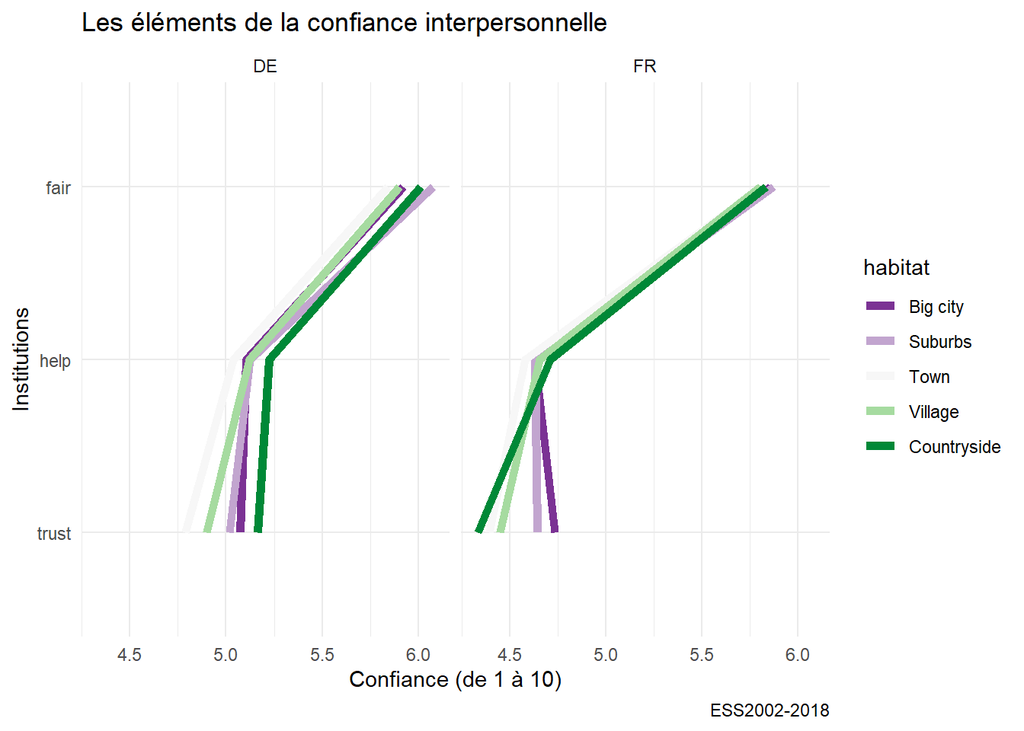

```r
rad<-df %>%
  group_by (habitat,cntry) %>%
  summarize(help=mean(help, na.rm=TRUE),
  fair=mean(fair, na.rm=TRUE),
  trust=mean(trust, na.rm=TRUE)) %>% filter(!is.na(habitat))

rad<-melt(rad)
ggplot(rad, aes(x=reorder(variable, value),y=value,group=habitat))+
  geom_line(aes(color=habitat), size=2)+coord_flip()+facet_grid(.~cntry)+
  theme_minimal()+scale_color_brewer(type="div",palette=3)+
  labs(title= "Les éléments de la confiance interpersonnelle", caption="ESS2002-2018",y= "Confiance (de 1 à 10)",x="Institutions")
```

## radar

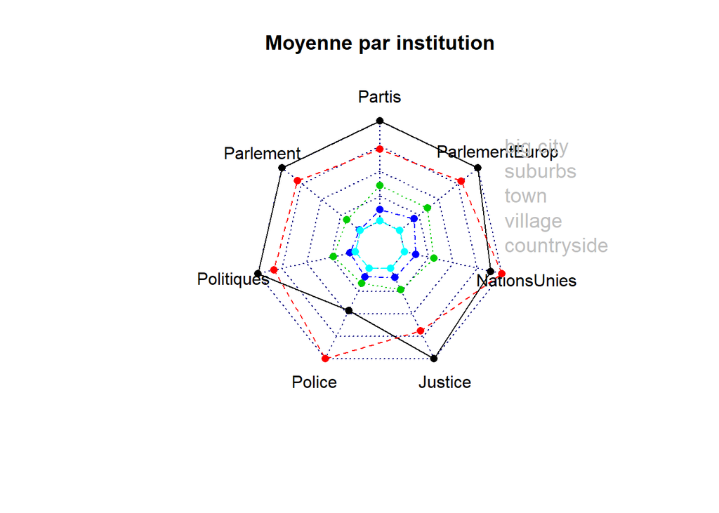

```r
library(fmsb)

rad<-df %>% filter(cntry=="FR") %>%
  group_by (habitat) %>%
  summarize(Partis=mean(Partis, na.rm=TRUE),
  Parlement=mean(Parlement, na.rm=TRUE),
  Politiques=mean(Politiques, na.rm=TRUE),
  Police=mean(Police, na.rm=TRUE),
  Justice=mean(Justice, na.rm=TRUE),
  NationsUnies=mean(NationsUnies, na.rm=TRUE),
  ParlementEurop=mean(ParlementEurop, na.rm=TRUE)) %>% filter(!is.na(habitat)) %>% dplyr::select(-habitat)

#on doit indiquer les valeurs minimale et maximale - la fonction rep permet de repeter (ici 7 fois pour les 7 variables/col)
data <- rbind(rep(7,7) , rep(3,7) , rad)
#l'autre method c'est ce choisir maxmin=FALSE

rownames(rad) <- c("big city", "suburbs" ,"town","village", "countryside")
radarchart(rad, axistype=0, seg=4, title="Moyenne par institution", maxmin=FALSE)
legend(x=0.7, y=1, legend = rownames(rad), bty = "n",text.col = "grey", cex=1.2, pt.cex=3)
```

# Un programme pour la suite

## Des chloropleth pour la géographie

### Les projection des variables

## Apres l’espace,le temps

Même si nous avons indiquer des manière de représenter une évolution, des techniqueplus spécifiques peuevent etre employées.

### Séries chronologiques

# Ressources

Un point de départ fondamental est la [gallery de ggplot](https://www.r-graph-gallery.com/),, elle présente de manière synthétique toute les types de figures qui peuvent être présentées. Avec du code facilement reproductible. Voici le [book de référence](https://ggplot2-book.org/), qui est au centre de ce cours. On aura besoin de manière assez systématique de manipuler les données avant de les représenter, [dplyr](http://larmarange.github.io/analyse-R/manipuler-les-donnees-avec-dplyr.html) nous permet de le faire aisément.

Ces outils s’appuient sur l’idée de [grammaire des graphiques](https://www.goodreads.com/book/show/2549408.The_Grammar_of_Graphics). En voici un [clair résumé](https://cfss.uchicago.edu/notes/grammar-of-graphics/).En français il y a toujours le [larmarange](http://larmarange.github.io/analyse-R/intro-ggplot2.html)

le graphisme est immportant. Une bibliothèque de modèle.